# Guía de trabajo programación con R

OCE - 386 INTRODUCCIÓN AL ANÁLISIS DE DATOS CON R

Dr. José A. Gallardo.

Pontificia Universidad Católica de Valparaíso  
jose.gallardo@pucv.cl

10 August 2021

#### **Introducción**

**R** es un lenguaje de programación orientado a *objetos*. Las funciones y comandos para trabajar con objetos están contenidas en librerías o **packages**, algunas de las cuales ya están habilitadas al iniciar cualquier proyecto de **R** como las librerías **{base}**, **{graphics}**, **{stats}** o **{datasets}**.

Esta guía se elaboró usando **Rmarkdown** y está en formato html, lo que permitió integrar texto de bajo nivel o **markdown** y códigos desplegables (botón **Code**) con la solución a los ejercicios propuestos.

Cuando realices los ejercicios intenta **no mirar** la respuesta, hasta que hayas trabajado duro en generarla tu mismo. Trabajar en equipo es la mejor manera de aprender y conseguir resultados de calidad. Si tienes dudas pregunta y si puedes ayudar a otro, hazlo.

#### **Objetivos de aprendizaje**

Los objetivos de aprendizaje de esta guía son:

**1).** Iniciar un proyecto de análisis de datos con **R** usando el software **[Rstudio.Cloud](https://rstudio.cloud/)**.

**2).** Escribir un código de programación o *script* con el **[software R](https://www.r-project.org/about.html)**.

**3).** Familiarizarse con la creación y manipulación de objetos con **R**.

#### **Objetos de uso frecuente en R**

[output not shown]

#### **Comandos**

A continuación, se presentan algunos comandos que deberás usar para resolver los ejercicios de esta guía. Otros, los aprenderás mientras vas ejecutando algunas instrucciones y otros, los deberás investigar por tu propia cuenta.

Este comando permite crear objetos  
**<-**  
Por ejemplo, el siguiente código crea un objeto llamado datos con 4 elementos denominados 1, 2, 3 y 4.

datos **<-** **c**(1,2,3,4)

Crea un data.frame  
**data.frame()**

Crea una matrix  
**matrix()**

Explora objetos  
**class()**  
**head()**  
**tail()** **length()**

Función genérica usada para resumir datos de un objeto  
**summary()**

## **Ejercicios**

### **Ejercicio 1.** **Conociendo un script**

Abre el archivo script_example.R y familiarízate con la estructura de un *script* de **R**, con la forma en que está estructurado y de cómo ejecutar comandos. Observa la importancia de establecer con claridad los **metadatos** de un *script* y que el simbolo **#** se usa frecuentemente para hacer comentarios. Finalmente, toma un tiempo y discute con tus compañeros cual es la función de los comandos que se ejecutan en el ejemplo.

### **Ejercicio 2.** **Crea tu propio script**

**a).** Ahora, crea tu propio *script* usando la barra de herramientas de **Rstudio**. Selecciona **File > New file > R script**. Guarda inmediatamente este script como **script_clase1_nombre_apellido**. Esto, es importante porque al finalizar la actividad deberás exportar el *script* y entregar tu tarea**

**b).** Crea los metadatos de tu *script* siguiendo el ejemplo anterior y haciendo referencia a la **tarea 1** y como primera tarea remueve los objetos de la sesión de trabajo usando **rm(list = ls())**.

### **Ejercicio 3.** **Trabajando con vectores**

**a).** Investiga la librería **datasets** y el set de datos *rivers* usando la función **help().**

```r
help("datasets")
# Esta librería o package contiene una variedad de set de datos de origen diverso.
```

```r
help("rivers")
# Este set de datos contiene el largo en millas de los 141 principales ríos de Norte América. Los datos fueron obtenidos desde el US Geological Survey.
```

**b).** Ejecuta los comandos **class()** y **str()** para determinar algunas propiedades del objeto *rivers*.

```r
class(rivers)
```

```
## [1] "numeric"
```

```r
str(rivers)
```

```
##  num [1:141] 735 320 325 392 524 ...
```

**c).** Comprueba que tipo de objeto es *rivers* usando las funciones lógicas **is.vector** e **is.data.frame.**

```r
is.data.frame(rivers)
```

```
## [1] FALSE
```

```r
is.vector(rivers)
```

```
## [1] TRUE
```

**d).** Crea un objeto llamado *datos* y almacena en él, el número de elementos del objeto *rivers*. A continuación, explora la función de los comandos **length()** y **cat()** y responde la siguiente pregunta ¿Cuántos elementos o datos tiene el objeto *rivers*?

```r
datos <- length(rivers)
cat("El objeto rivers tiene",datos,"datos")
```

```
## El objeto rivers tiene 141 datos
```

**e).** Ejecuta los comandos **head()** y **tail()** para inspeccionar los elementos contenidos al inicio y al final del objeto *rivers*.

```r
head(rivers)
```

```
## [1] 735 320 325 392 524 450
```

```r
tail(rivers)
```

```
## [1]  500  720  270  430  671 1770
```

**f).** Usa la función **summary()** para obtener algunos estadísticos relevantes del objeto *rivers*.

```r
summary(rivers)
```

```
##    Min. 1st Qu.  Median    Mean 3rd Qu.    Max.
##   135.0   310.0   425.0   591.2   680.0  3710.0
```

**g).** ¿Cuál es el rango de los datos contenidos en *rivers*?. Usa el comando **cat()** para redactar tu respuesta.

```r
rango <- max(rivers)-min(rivers)
cat("El rango de datos del objeto rivers es",rango, "millas")
```

```
## El rango de datos del objeto rivers es 3575 millas
```

**h).** Crea un histograma del objeto *rivers*. Incluye los argumentos necesarios para agregar una leyenda a la figura, etiquetar los ejes y colorearla con el color de tu preferencia.

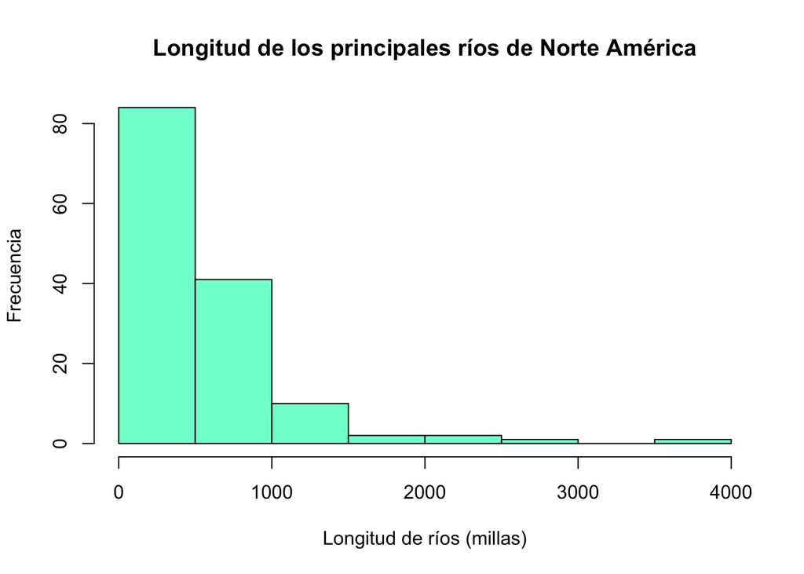

```r
hist(rivers, main = "Longitud de los principales ríos de Norte América",
     xlab = "Longitud de ríos (millas)", ylab = "Frecuencia", col = "Aquamarine")
```

### **Ejercicio 4.** **Trabajando con Dataframe**

**a).** Investiga y explora el set de datos *BOD* de la librería **datasets** con las funciones **help()** y **summary()**.

```r
help(BOD)
# El set de datos BOD proviene de una tesis de magister en el cual se analiza la demanda bioquímica de oxígeno versus el tiempo en una evaluación de calidad de agua.
```

```r
summary(BOD)
```

```
##       Time           demand
##  Min.   :1.000   Min.   : 8.30
##  1st Qu.:2.250   1st Qu.:11.62
##  Median :3.500   Median :15.80
##  Mean   :3.667   Mean   :14.83
##  3rd Qu.:4.750   3rd Qu.:18.25
##  Max.   :7.000   Max.   :19.80
```

**b).** ¿Qué propiedades y estructura tiene el objeto *BOD*?

```r
str(BOD)
```

```
## 'data.frame':    6 obs. of  2 variables:
##  $ Time  : num  1 2 3 4 5 7
##  $ demand: num  8.3 10.3 19 16 15.6 19.8
##  - attr(*, "reference")= chr "A1.4, p. 270"
```

```r
BOD[3,1]
```

```
## [1] 3
```

**c).** Gráfique la relación entre ambas variables usando la función **plot()**.

**Tips 2:** Dado que el data.frame tiene 2 variables debe indicar claramente que variable usará en cada eje **data.frame$variable**.

[figure not shown]

```r
plot(BOD$Time ~ BOD$demand, main = "BOD", xlab = "Time (days)", ylab = "Demand (mg/l)")
```

**d).** Calcule la correlación entre las variables Time y Demand usando la función **cor()**.

```r
cor(BOD$Time,BOD$demand)
```

```
## [1] 0.8030693
```